# CA0

به نام خدا  
دانشگاه تهران - دانشکده مهندسی برق و کامپیوتر  
هوش مصنوعی  
پاییز ۱۴۰۰

پروژه صفر

حسام اسداله‌زاده  
شماره دانشجویی: ۸۱۰۱۹۸۳۴۶

```python
import numpy as np
import pandas as pd
from matplotlib import pyplot as plt
```

# Q1: Reading Data

```python
data = pd.read_csv("FuelConsumptionCo2.csv")
data.head()
```

|  | Unnamed: 0 | MODELYEAR | MAKE | MODEL | VEHICLECLASS | ENGINESIZE | CYLINDERS | TRANSMISSION | FUELTYPE | FUELCONSUMPTION_CITY | FUELCONSUMPTION_HWY | FUELCONSUMPTION_COMB | FUELCONSUMPTION_COMB_MPG | CO2EMISSIONS |
| --- | --- | --- | --- | --- | --- | --- | --- | --- | --- | --- | --- | --- | --- | --- |
| 0 | 0 | 2014 | ACURA | ILX | COMPACT | 2.0 | 4.0 | AS5 | Z | 9.9 | 6.7 | 8.5 | 33 | 196.0 |
| 1 | 1 | 2014 | ACURA | ILX | COMPACT | 2.4 | 4.0 | M6 | Z | 11.2 | 7.7 | 9.6 | 29 | 221.0 |
| 2 | 2 | 2014 | ACURA | ILX HYBRID | COMPACT | 1.5 | 4.0 | AV7 | Z | 6.0 | 5.8 | 5.9 | 48 | 136.0 |
| 3 | 3 | 2014 | ACURA | MDX 4WD | SUV - SMALL | 3.5 | 6.0 | AS6 | Z | 12.7 | 9.1 | 11.1 | 25 | NaN |
| 4 | 4 | 2014 | ACURA | RDX AWD | SUV - SMALL | 3.5 | 6.0 | AS6 | Z | 12.1 | 8.7 | 10.6 | 27 | 244.0 |

`head()`: shows us first 5 rows of the dataset. So we can take a look at column titles and their values.

```python
data.tail()
```

|  | Unnamed: 0 | MODELYEAR | MAKE | MODEL | VEHICLECLASS | ENGINESIZE | CYLINDERS | TRANSMISSION | FUELTYPE | FUELCONSUMPTION_CITY | FUELCONSUMPTION_HWY | FUELCONSUMPTION_COMB | FUELCONSUMPTION_COMB_MPG | CO2EMISSIONS |
| --- | --- | --- | --- | --- | --- | --- | --- | --- | --- | --- | --- | --- | --- | --- |
| 1062 | 1062 | 2014 | VOLVO | XC60 AWD | SUV - SMALL | 3.0 | 6.0 | AS6 | X | 13.4 | 9.8 | 11.8 | 24 | 271.0 |
| 1063 | 1063 | 2014 | VOLVO | XC60 AWD | SUV - SMALL | 3.2 | 6.0 | AS6 | X | 13.2 | 9.5 | 11.5 | 25 | 264.0 |
| 1064 | 1064 | 2014 | VOLVO | XC70 AWD | SUV - SMALL | 3.0 | 6.0 | AS6 | X | 13.4 | 9.8 | 11.8 | 24 | 271.0 |
| 1065 | 1065 | 2014 | VOLVO | XC70 AWD | SUV - SMALL | 3.2 | 6.0 | AS6 | X | 12.9 | 9.3 | 11.3 | 25 | 260.0 |
| 1066 | 1066 | 2014 | VOLVO | XC90 AWD | SUV - STANDARD | 3.2 | 6.0 | AS6 | X | 14.9 | 10.2 | 12.8 | 22 | 294.0 |

`tail()`: shows us last 5 rows of the dataset. This method can be used beside `head()` to have a better intuition about the whole dataset.

```python
data.describe()
```

|  | Unnamed: 0 | MODELYEAR | ENGINESIZE | CYLINDERS | FUELCONSUMPTION_CITY | FUELCONSUMPTION_HWY | FUELCONSUMPTION_COMB | FUELCONSUMPTION_COMB_MPG | CO2EMISSIONS |
| --- | --- | --- | --- | --- | --- | --- | --- | --- | --- |
| count | 1067.000000 | 1067.0 | 1040.000000 | 1033.000000 | 1067.000000 | 1067.000000 | 1067.000000 | 1067.000000 | 964.000000 |
| mean | 533.000000 | 2014.0 | 3.324038 | 5.797677 | 13.296532 | 9.474602 | 11.580881 | 26.441425 | 256.741701 |
| std | 308.160672 | 0.0 | 1.411400 | 1.807262 | 4.101253 | 2.794510 | 3.485595 | 7.468702 | 63.265308 |
| min | 0.000000 | 2014.0 | 1.000000 | 3.000000 | 4.600000 | 4.900000 | 4.700000 | 11.000000 | 108.000000 |
| 25% | 266.500000 | 2014.0 | 2.000000 | 4.000000 | 10.250000 | 7.500000 | 9.000000 | 21.000000 | 209.000000 |
| 50% | 533.000000 | 2014.0 | 3.300000 | 6.000000 | 12.600000 | 8.800000 | 10.900000 | 26.000000 | 251.000000 |
| 75% | 799.500000 | 2014.0 | 4.200000 | 8.000000 | 15.550000 | 10.850000 | 13.350000 | 31.000000 | 294.000000 |
| max | 1066.000000 | 2014.0 | 8.400000 | 12.000000 | 30.200000 | 20.500000 | 25.800000 | 60.000000 | 437.000000 |

`describe()`: this method calculates several quantities of the numerical columns like the **count** of non-NaN values in that column and their **mean**, **std**, **min**, ... so this gives us an overall view about numerical columns of the dataset.

# Q2: DataFrame.info()

```python
data.info()
```

```
<class 'pandas.core.frame.DataFrame'>
RangeIndex: 1067 entries, 0 to 1066
Data columns (total 14 columns):
 #   Column                    Non-Null Count  Dtype
---  ------                    --------------  -----
 0   Unnamed: 0                1067 non-null   int64
 1   MODELYEAR                 1067 non-null   int64
 2   MAKE                      1067 non-null   object
 3   MODEL                     1058 non-null   object
 4   VEHICLECLASS              1067 non-null   object
 5   ENGINESIZE                1040 non-null   float64
 6   CYLINDERS                 1033 non-null   float64
 7   TRANSMISSION              1067 non-null   object
 8   FUELTYPE                  996 non-null    object
 9   FUELCONSUMPTION_CITY      1067 non-null   float64
 10  FUELCONSUMPTION_HWY       1067 non-null   float64
 11  FUELCONSUMPTION_COMB      1067 non-null   float64
 12  FUELCONSUMPTION_COMB_MPG  1067 non-null   int64
 13  CO2EMISSIONS              964 non-null    float64
dtypes: float64(6), int64(3), object(5)
memory usage: 116.8+ KB
```

We can observe that 5 columns are categorical and 9 columns are numerical (`int` or `float`)

```python
fueltype = {'X': 0, 'E': 1, 'D': 2, 'Z': 3}
data['FUELTYPE'].replace(fueltype, inplace=True)
data.head()
```

|  | Unnamed: 0 | MODELYEAR | MAKE | MODEL | VEHICLECLASS | ENGINESIZE | CYLINDERS | TRANSMISSION | FUELTYPE | FUELCONSUMPTION_CITY | FUELCONSUMPTION_HWY | FUELCONSUMPTION_COMB | FUELCONSUMPTION_COMB_MPG | CO2EMISSIONS |
| --- | --- | --- | --- | --- | --- | --- | --- | --- | --- | --- | --- | --- | --- | --- |
| 0 | 0 | 2014 | ACURA | ILX | COMPACT | 2.0 | 4.0 | AS5 | 3.0 | 9.9 | 6.7 | 8.5 | 33 | 196.0 |
| 1 | 1 | 2014 | ACURA | ILX | COMPACT | 2.4 | 4.0 | M6 | 3.0 | 11.2 | 7.7 | 9.6 | 29 | 221.0 |
| 2 | 2 | 2014 | ACURA | ILX HYBRID | COMPACT | 1.5 | 4.0 | AV7 | 3.0 | 6.0 | 5.8 | 5.9 | 48 | 136.0 |
| 3 | 3 | 2014 | ACURA | MDX 4WD | SUV - SMALL | 3.5 | 6.0 | AS6 | 3.0 | 12.7 | 9.1 | 11.1 | 25 | NaN |
| 4 | 4 | 2014 | ACURA | RDX AWD | SUV - SMALL | 3.5 | 6.0 | AS6 | 3.0 | 12.1 | 8.7 | 10.6 | 27 | 244.0 |

```python
data.tail()
```

|  | Unnamed: 0 | MODELYEAR | MAKE | MODEL | VEHICLECLASS | ENGINESIZE | CYLINDERS | TRANSMISSION | FUELTYPE | FUELCONSUMPTION_CITY | FUELCONSUMPTION_HWY | FUELCONSUMPTION_COMB | FUELCONSUMPTION_COMB_MPG | CO2EMISSIONS |
| --- | --- | --- | --- | --- | --- | --- | --- | --- | --- | --- | --- | --- | --- | --- |
| 1062 | 1062 | 2014 | VOLVO | XC60 AWD | SUV - SMALL | 3.0 | 6.0 | AS6 | 0.0 | 13.4 | 9.8 | 11.8 | 24 | 271.0 |
| 1063 | 1063 | 2014 | VOLVO | XC60 AWD | SUV - SMALL | 3.2 | 6.0 | AS6 | 0.0 | 13.2 | 9.5 | 11.5 | 25 | 264.0 |
| 1064 | 1064 | 2014 | VOLVO | XC70 AWD | SUV - SMALL | 3.0 | 6.0 | AS6 | 0.0 | 13.4 | 9.8 | 11.8 | 24 | 271.0 |
| 1065 | 1065 | 2014 | VOLVO | XC70 AWD | SUV - SMALL | 3.2 | 6.0 | AS6 | 0.0 | 12.9 | 9.3 | 11.3 | 25 | 260.0 |
| 1066 | 1066 | 2014 | VOLVO | XC90 AWD | SUV - STANDARD | 3.2 | 6.0 | AS6 | 0.0 | 14.9 | 10.2 | 12.8 | 22 | 294.0 |

```python
data.info()
```

```
<class 'pandas.core.frame.DataFrame'>
RangeIndex: 1067 entries, 0 to 1066
Data columns (total 14 columns):
 #   Column                    Non-Null Count  Dtype
---  ------                    --------------  -----
 0   Unnamed: 0                1067 non-null   int64
 1   MODELYEAR                 1067 non-null   int64
 2   MAKE                      1067 non-null   object
 3   MODEL                     1058 non-null   object
 4   VEHICLECLASS              1067 non-null   object
 5   ENGINESIZE                1040 non-null   float64
 6   CYLINDERS                 1033 non-null   float64
 7   TRANSMISSION              1067 non-null   object
 8   FUELTYPE                  996 non-null    float64
 9   FUELCONSUMPTION_CITY      1067 non-null   float64
 10  FUELCONSUMPTION_HWY       1067 non-null   float64
 11  FUELCONSUMPTION_COMB      1067 non-null   float64
 12  FUELCONSUMPTION_COMB_MPG  1067 non-null   int64
 13  CO2EMISSIONS              964 non-null    float64
dtypes: float64(7), int64(3), object(4)
memory usage: 116.8+ KB
```

# Q3: Replacing missing values

```python
print("Number of NaN data in each column is: ")
data.isna().sum()
```

```
Number of NaN data in each column is:
```

```
Unnamed: 0                    0
MODELYEAR                     0
MAKE                          0
MODEL                         9
VEHICLECLASS                  0
ENGINESIZE                   27
CYLINDERS                    34
TRANSMISSION                  0
FUELTYPE                     71
FUELCONSUMPTION_CITY          0
FUELCONSUMPTION_HWY           0
FUELCONSUMPTION_COMB          0
FUELCONSUMPTION_COMB_MPG      0
CO2EMISSIONS                103
dtype: int64
```

```python
data['MODEL'].fillna(value=data['MODEL'].mode()[0], inplace=True)
data['ENGINESIZE'].fillna(value=data['ENGINESIZE'].mean(), inplace=True)
data['CYLINDERS'].fillna(value=data['CYLINDERS'].mean(), inplace=True)
data['FUELTYPE'].fillna(value=data['FUELTYPE'].mode()[0], inplace=True)
data.info()
```

```
<class 'pandas.core.frame.DataFrame'>
RangeIndex: 1067 entries, 0 to 1066
Data columns (total 14 columns):
 #   Column                    Non-Null Count  Dtype
---  ------                    --------------  -----
 0   Unnamed: 0                1067 non-null   int64
 1   MODELYEAR                 1067 non-null   int64
 2   MAKE                      1067 non-null   object
 3   MODEL                     1067 non-null   object
 4   VEHICLECLASS              1067 non-null   object
 5   ENGINESIZE                1067 non-null   float64
 6   CYLINDERS                 1067 non-null   float64
 7   TRANSMISSION              1067 non-null   object
 8   FUELTYPE                  1067 non-null   float64
 9   FUELCONSUMPTION_CITY      1067 non-null   float64
 10  FUELCONSUMPTION_HWY       1067 non-null   float64
 11  FUELCONSUMPTION_COMB      1067 non-null   float64
 12  FUELCONSUMPTION_COMB_MPG  1067 non-null   int64
 13  CO2EMISSIONS              964 non-null    float64
dtypes: float64(7), int64(3), object(4)
memory usage: 116.8+ KB
```

```python
data_nan = data[data['CO2EMISSIONS'].isna()]
data_nan.info()
```

```
<class 'pandas.core.frame.DataFrame'>
Int64Index: 103 entries, 3 to 1053
Data columns (total 14 columns):
 #   Column                    Non-Null Count  Dtype
---  ------                    --------------  -----
 0   Unnamed: 0                103 non-null    int64
 1   MODELYEAR                 103 non-null    int64
 2   MAKE                      103 non-null    object
 3   MODEL                     103 non-null    object
 4   VEHICLECLASS              103 non-null    object
 5   ENGINESIZE                103 non-null    float64
 6   CYLINDERS                 103 non-null    float64
 7   TRANSMISSION              103 non-null    object
 8   FUELTYPE                  103 non-null    float64
 9   FUELCONSUMPTION_CITY      103 non-null    float64
 10  FUELCONSUMPTION_HWY       103 non-null    float64
 11  FUELCONSUMPTION_COMB      103 non-null    float64
 12  FUELCONSUMPTION_COMB_MPG  103 non-null    int64
 13  CO2EMISSIONS              0 non-null      float64
dtypes: float64(7), int64(3), object(4)
memory usage: 12.1+ KB
```

```python
df = data[data['CO2EMISSIONS'].notna()]
df.info()
```

```
<class 'pandas.core.frame.DataFrame'>
Int64Index: 964 entries, 0 to 1066
Data columns (total 14 columns):
 #   Column                    Non-Null Count  Dtype
---  ------                    --------------  -----
 0   Unnamed: 0                964 non-null    int64
 1   MODELYEAR                 964 non-null    int64
 2   MAKE                      964 non-null    object
 3   MODEL                     964 non-null    object
 4   VEHICLECLASS              964 non-null    object
 5   ENGINESIZE                964 non-null    float64
 6   CYLINDERS                 964 non-null    float64
 7   TRANSMISSION              964 non-null    object
 8   FUELTYPE                  964 non-null    float64
 9   FUELCONSUMPTION_CITY      964 non-null    float64
 10  FUELCONSUMPTION_HWY       964 non-null    float64
 11  FUELCONSUMPTION_COMB      964 non-null    float64
 12  FUELCONSUMPTION_COMB_MPG  964 non-null    int64
 13  CO2EMISSIONS              964 non-null    float64
dtypes: float64(7), int64(3), object(4)
memory usage: 113.0+ KB
```

Now `df` is our cleansed data and it's preprocessed. It doesn't have any NaN values anymore.

**pros and cons of replacing NaN values with mean value:**

- pros:
  1. Mean value is the first and somehow best estimator for missing values
  2. It's Simple! Calculating the mean is really easy and has a low cost of calculation
- cons:
  1. we can't use it for categorical data.
  2. Using mean for some numerical data would be meaningless. for example number of fingers of an animal couldn't be fractional.
  3. although it's easy to calculate, it may not be a good estimator in case of existing several **outliers** in the data.

# Q4: Vectorized FuelConsumption:

```python
import time
```

```python
t = time.time()
print('mean =', df[df['CO2EMISSIONS'] < 240]['FUELCONSUMPTION_CITY'].mean())
print('vectorized time:', time.time() - t)
```

```
mean = 10.03781902552204
vectorized time: 0.0019936561584472656
```

```python
t = time.time()
print('mean =', df[df['CO2EMISSIONS'] > 300]['FUELCONSUMPTION_CITY'].mean())
print('vectorized time:', time.time() - t)
```

```
mean = 18.663255813953487
vectorized time: 0.0019953250885009766
```

# Q5: Using Loops:

```python
t = time.time()
sum_fuel = 0
num = 0
for i in df['Unnamed: 0']:
    if(df.loc[i, 'CO2EMISSIONS'] < 240):
        sum_fuel += df.loc[i, 'FUELCONSUMPTION_CITY']
        num += 1
print('mean =', sum_fuel/num)
print('loop time:', time.time() - t)
```

```
mean = 10.037819025522042
loop time: 0.017975568771362305
```

```python
t = time.time()
sum_fuel = 0
num = 0
for i in df['Unnamed: 0']:
    if(df.loc[i, 'CO2EMISSIONS'] > 300):
        sum_fuel += df.loc[i, 'FUELCONSUMPTION_CITY']
        num += 1
print('mean =', sum_fuel/num)
print('loop time:', time.time() - t)
```

```
mean = 18.663255813953487
loop time: 0.012967824935913086
```

Using Vectorization, approximately **1-2ms** is needed to calculate the mean.  
Using Loops, approximately **12-18ms** is needed to calculate the mean.  
So vectorized calculation is much more faster.

# Q6: Drawing histograms for numerical data:

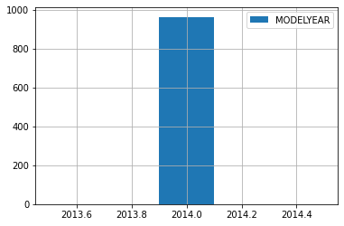

```python
df['MODELYEAR'].hist(bins=5, legend=True)
```

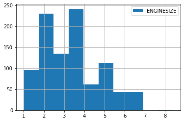

```python
df['ENGINESIZE'].hist(legend=True)
```

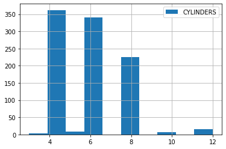

```python
df['CYLINDERS'].hist(legend=True)
```

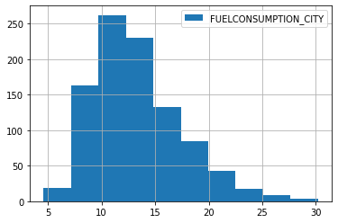

```python
df['FUELCONSUMPTION_CITY'].hist(legend=True)
```

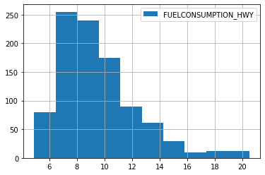

```python
df['FUELCONSUMPTION_HWY'].hist(legend=True)
```

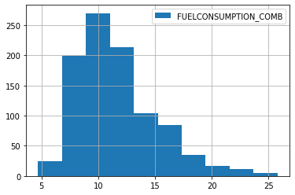

```python
df['FUELCONSUMPTION_COMB'].hist(legend=True)
```

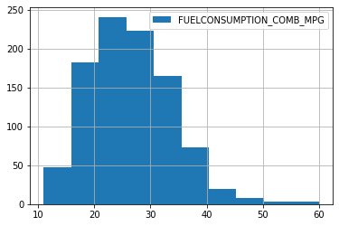

```python
df['FUELCONSUMPTION_COMB_MPG'].hist(legend=True)
```

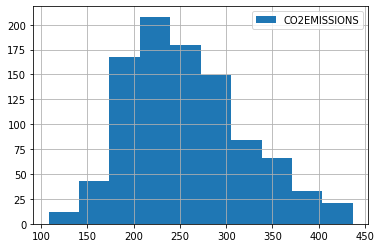

```python
df['CO2EMISSIONS'].hist(legend=True)
```

```
array([[<AxesSubplot:title={'center':'Unnamed: 0'}>,
        <AxesSubplot:title={'center':'MODELYEAR'}>,
        <AxesSubplot:title={'center':'ENGINESIZE'}>],
       [<AxesSubplot:title={'center':'CYLINDERS'}>,
        <AxesSubplot:title={'center':'FUELTYPE'}>,
        <AxesSubplot:title={'center':'FUELCONSUMPTION_CITY'}>],
       [<AxesSubplot:title={'center':'FUELCONSUMPTION_HWY'}>,
        <AxesSubplot:title={'center':'FUELCONSUMPTION_COMB'}>,
        <AxesSubplot:title={'center':'FUELCONSUMPTION_COMB_MPG'}>],
       [<AxesSubplot:title={'center':'CO2EMISSIONS'}>, <AxesSubplot:>,
        <AxesSubplot:>]], dtype=object)
```

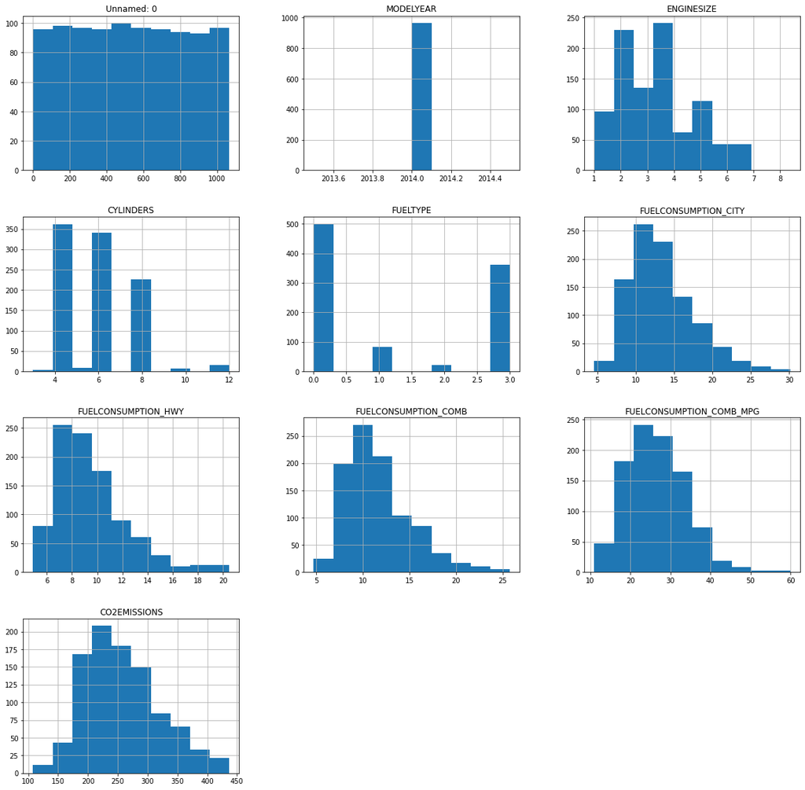

```python
df.hist(figsize=(20,20))
```

```python
df = df.drop(columns=['FUELTYPE', 'Unnamed: 0', 'MAKE', 'MODEL', 'VEHICLECLASS', 'TRANSMISSION'], axis=1)
df.head()
```

|  | MODELYEAR | ENGINESIZE | CYLINDERS | FUELCONSUMPTION_CITY | FUELCONSUMPTION_HWY | FUELCONSUMPTION_COMB | FUELCONSUMPTION_COMB_MPG | CO2EMISSIONS |
| --- | --- | --- | --- | --- | --- | --- | --- | --- |
| 0 | 2014 | 2.0 | 4.0 | 9.9 | 6.7 | 8.5 | 33 | 196.0 |
| 1 | 2014 | 2.4 | 4.0 | 11.2 | 7.7 | 9.6 | 29 | 221.0 |
| 2 | 2014 | 1.5 | 4.0 | 6.0 | 5.8 | 5.9 | 48 | 136.0 |
| 4 | 2014 | 3.5 | 6.0 | 12.1 | 8.7 | 10.6 | 27 | 244.0 |
| 5 | 2014 | 3.5 | 6.0 | 11.9 | 7.7 | 10.0 | 28 | 230.0 |

# Q7: Normalizing data

```python
prior_input_mean = df['FUELCONSUMPTION_COMB'].mean()
prior_input_std = df['FUELCONSUMPTION_COMB'].std()
prior_output_mean = df['CO2EMISSIONS'].mean()
prior_output_std = df['CO2EMISSIONS'].std()

for c in list(df.columns):
    if df[c].std() != 0:
        df[c] = (df[c] - df[c].mean())/df[c].std()
```

```python
df.head()
```

|  | MODELYEAR | ENGINESIZE | CYLINDERS | FUELCONSUMPTION_CITY | FUELCONSUMPTION_HWY | FUELCONSUMPTION_COMB | FUELCONSUMPTION_COMB_MPG | CO2EMISSIONS |
| --- | --- | --- | --- | --- | --- | --- | --- | --- |
| 0 | 2014 | -0.973622 | -1.024099 | -0.833605 | -0.994870 | -0.888216 | 0.886286 | -0.960111 |
| 1 | 2014 | -0.683744 | -1.024099 | -0.519842 | -0.641939 | -0.576247 | 0.352882 | -0.564949 |
| 2 | 2014 | -1.335970 | -1.024099 | -1.774893 | -1.312508 | -1.625596 | 2.886552 | -1.908498 |
| 4 | 2014 | 0.113422 | 0.100355 | -0.302621 | -0.289008 | -0.292640 | 0.086180 | -0.201401 |
| 5 | 2014 | 0.113422 | 0.100355 | -0.350893 | -0.641939 | -0.462804 | 0.219531 | -0.422691 |

# Q8: Scatterplot

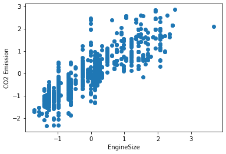

```python
plt.scatter(x = df['ENGINESIZE'], y = df['CO2EMISSIONS'])
plt.xlabel('EngineSize')
plt.ylabel('CO2 Emission')
```

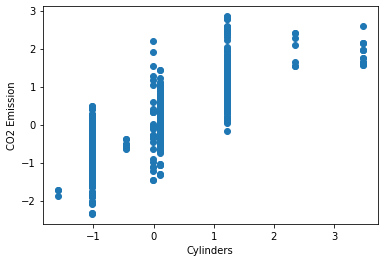

```python
plt.scatter(x = df['CYLINDERS'], y = df['CO2EMISSIONS'])
plt.xlabel('Cylinders')
plt.ylabel('CO2 Emission')
```

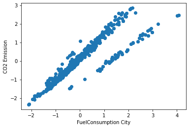

```python
plt.scatter(x = df['FUELCONSUMPTION_CITY'], y = df['CO2EMISSIONS'])
plt.xlabel('FuelConsumption City')
plt.ylabel('CO2 Emission')
```

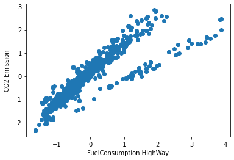

```python
plt.scatter(x = df['FUELCONSUMPTION_HWY'], y = df['CO2EMISSIONS'])
plt.xlabel('FuelConsumption HighWay')
plt.ylabel('CO2 Emission')
```

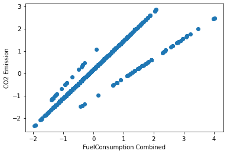

```python
plt.scatter(x = df['FUELCONSUMPTION_COMB'], y = df['CO2EMISSIONS'])
plt.xlabel('FuelConsumption Combined')
plt.ylabel('CO2 Emission')
```

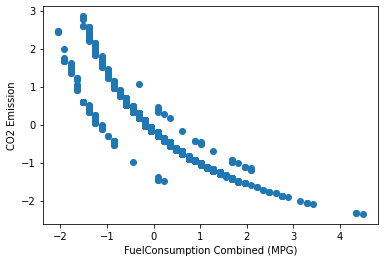

```python
plt.scatter(x = df['FUELCONSUMPTION_COMB_MPG'], y = df['CO2EMISSIONS'])
plt.xlabel('FuelConsumption Combined (MPG)')
plt.ylabel('CO2 Emission')
```

I think **FUELCONSUMPTION_COMB** has the best linear correlation with CO2 emission. (in comparison with other features)

# Q9:

```python
df_final = df[['FUELCONSUMPTION_COMB', 'CO2EMISSIONS']]
df_final.head()
```

|  | FUELCONSUMPTION_COMB | CO2EMISSIONS |
| --- | --- | --- |
| 0 | -0.888216 | -0.960111 |
| 1 | -0.576247 | -0.564949 |
| 2 | -1.625596 | -1.908498 |
| 4 | -0.292640 | -0.201401 |
| 5 | -0.462804 | -0.422691 |

# Q10: Estimating function

Using Normal Equation:

```python
X0 = [1] * len(df_final)
X1 = list(df_final['FUELCONSUMPTION_COMB'])
X = np.array([X0, X1])
X = X.T
theta = np.linalg.inv(X.T @ X)
theta = theta @ X.T
theta = theta @ np.array(df_final['CO2EMISSIONS'])
```

```python
model = theta[0] + theta[1] * df_final['FUELCONSUMPTION_COMB']
```

# Q11: Drawing our model:

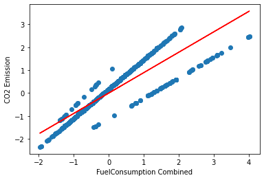

```python
plt.scatter(x = df_final['FUELCONSUMPTION_COMB'], y = df_final['CO2EMISSIONS'])
plt.xlabel('FuelConsumption Combined')
plt.ylabel('CO2 Emission')
plt.plot(df_final['FUELCONSUMPTION_COMB'], model, c='r')
```

```python
def MSE(y, model, size):
    return np.sum((y-model)**2)/size
```

```python
print("Mean Squared Error =", MSE(df_final['CO2EMISSIONS'], model, len(df_final)))
```

```
Mean Squared Error = 0.2100171470129475
```

# Q12: Predicting NaN values:

```python
data_nan = data_nan[['FUELCONSUMPTION_COMB', 'CO2EMISSIONS']]
data_nan.head()
```

|  | FUELCONSUMPTION_COMB | CO2EMISSIONS |
| --- | --- | --- |
| 3 | 11.1 | NaN |
| 20 | 10.0 | NaN |
| 30 | 11.2 | NaN |
| 42 | 13.2 | NaN |
| 43 | 10.9 | NaN |

```python
data_nan['FUELCONSUMPTION_COMB'] = (data_nan['FUELCONSUMPTION_COMB']-prior_input_mean)/prior_input_std
pred = theta[0] + theta[1] * data_nan['FUELCONSUMPTION_COMB']
pred = pred * prior_output_std + prior_output_mean
print(pred)
```

```
3       248.261254
20      230.721434
30      249.855783
42      281.746366
43      245.072196
           ...
1022    221.154259
1027    227.532375
1051    241.883138
1052    256.233900
1053    241.883138
Name: FUELCONSUMPTION_COMB, Length: 103, dtype: float64
```

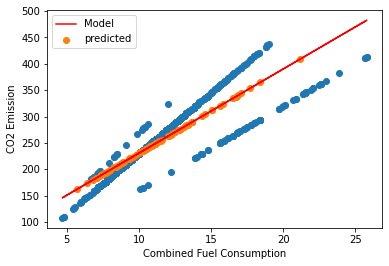

```python
plt.scatter(data['FUELCONSUMPTION_COMB'], data['CO2EMISSIONS'])
plt.plot(df_final['FUELCONSUMPTION_COMB']*prior_input_std+prior_input_mean, model*prior_output_std + prior_output_mean,
         label='Model', c='r')
plt.scatter(data_nan['FUELCONSUMPTION_COMB']*prior_input_std+prior_input_mean, pred, label = 'predicted')
plt.legend()
plt.xlabel('Combined Fuel Consumption')
plt.ylabel('CO2 Emission')
```

```python
pred.to_csv('pred.csv')
```